## 쇼핑몰 리뷰 평점 분류

# I. 데이터 살펴보기

모든 데이터 분석은 데이터를 먼저 살펴보아야 합니다. 바로 데이터를 살펴보는 일입니다.  
주어진 데이터를 살펴보며 데이터의 모양과 대략적인 내용을 파악하고, 무슨 분석이 가능한지 확인하여 분석의 방향을 잡는 과정이 필요합니다.

## 1. 데이터 준비

먼저 분석하려는 데이터를 작업장으로 가져오는 작업이 필요합니다.

pandas 라이브러리는 엑셀과 같은 행과 열로 이루어진 테이블(table) 형식의 데이터를 편하게 다루도록 해주는 라이브러리입니다.

```python
from google.colab import drive
drive.mount('/content/drive')
```

```python
import pandas as pd

#csv 형식의 training 데이터를 로드합니다.
train = pd.read_csv('/content/drive/MyDrive/텍스트기반/train.csv')
```

## 2. 데이터 확인

데이터를 살펴보았습니다.

처음 데이터를 살펴 볼 때에는 pandas의 **앞부분 :head()**, **뒷부분 : tail()** 그리고 **데이터의 형태 : info()** 메소드를 활용하여 데이터를 살펴보는 경우가 많습니다.

이는 데이터와 처음과 끝을 살펴봄으로서, **이상치나 결측치**와 같은 데이터를 살펴보기 위함입니다.

```python
# 데이터를 살펴보기 위해 데이터 최상단의 5줄을 표시합니다.
train.head()
```

|  | id | reviews | target |
| --- | --- | --- | --- |
| 0 | 0 | 조아요 처음구입 싸게햇어요 | 2 |
| 1 | 1 | 생각보다 잘 안돼요 매지 바른지 하루밖에 안됐는데ㅠㅠ 25천원가량 주고 사기 너무 ... | 1 |
| 2 | 2 | 디자인은괜찮은데 상품이 금이가서 교환했는데 두번째받은상품도 까져있고 안쪽에 금이가져... | 2 |
| 3 | 3 | 기전에 이 제품말고 이마트 트레이더스에서만 팔던 프리미엄 제품을 사용했었습니다. 샘... | 2 |
| 4 | 4 | 튼튼하고 손목을 잘 받쳐주네요~ | 5 |

```python
# 데이터를 살펴보기 위해 데이터 최하단의 5줄을 표시합니다.
train.tail()
```

|  | id | reviews | target |
| --- | --- | --- | --- |
| 24995 | 24995 | 일단향이너무너무좋은데지속력만좋다면좋겠지만..워낙저렴해그래도좋아여 | 5 |
| 24996 | 24996 | 동일한 업체에서 발송하고 한 상자로 배송되었는데 택배비는 이중 처리되었습니다. | 2 |
| 24997 | 24997 | 향이 좋아요!! 다른 향도 시켜보고 싶어요 | 4 |
| 24998 | 24998 | 펼쳐보니 끝부분쯤에 50cm정도 찟어져 있습니다 날짜관계로 구냥 사용합니다 | 2 |
| 24999 | 24999 | 호호애미 제품은 늘 믿고 써요 | 5 |

```python
# 데이터 결측치 및 변수들의 타입 확인
train.info()
```

```
<class 'pandas.core.frame.DataFrame'>
RangeIndex: 25000 entries, 0 to 24999
Data columns (total 3 columns):
 #   Column   Non-Null Count  Dtype
---  ------   --------------  -----
 0   id       25000 non-null  int64
 1   reviews  25000 non-null  object
 2   target   25000 non-null  int64
dtypes: int64(2), object(1)
memory usage: 586.1+ KB
```

info() 메소드를 이용해 데이터 결측치 및 변수들의 타입을 확인해본 결과,  
타겟 변수를 포함하여 총 3개의 변수와 25000 행으로 이루어져 있습니다.

Non-Null Count 부분을 보니 모든 행에서 결측치(NA)는 없었습니다

```python
!pip install tensorflow_text
!pip install translate
!sudo apt-get install -y fonts-nanum
!sudo fc-cache -fv
!rm ~/.cache/matplotlib -rf
```

[output not shown]

```python
df = train
```

**target의 값 시각화**

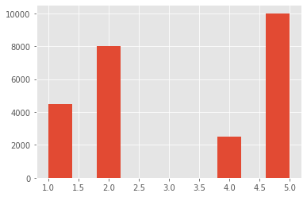

```python
df['target'].hist()
```

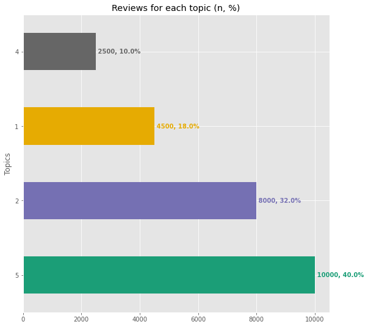

```python
import numpy as np
import matplotlib.pyplot as plt
plt.style.use('ggplot')


num_classes = len(df["target"].value_counts())

colors = plt.cm.Dark2(np.linspace(0, 1, num_classes))
iter_color = iter(colors)

df['target'].value_counts().plot.barh(title="Reviews for each topic (n, %)",
                                                 ylabel="Topics",
                                                 color=colors,
                                                 figsize=(9,9))

for i, v in enumerate(df['target'].value_counts()):
  c = next(iter_color)
  plt.text(v, i,
           " "+str(v)+", "+str(round(v*100/df.shape[0],2))+"%",
           color=c,
           va='center',
           fontweight='bold')
```

# II. 데이터 전처리

## 1. Feature Selection

모델링을 하기 앞서, 독립변수 X와 종속변수(타겟변수) y를 설정해야 합니다.

우리의 목적은 주어진 쇼핑몰 리뷰 데이터(독립변수)를 이용하여 평점(target)을 예측하는 것입니다.

리뷰가 X 평점 Y 로 나눠줍니다!

```python
# training 데이터에서 변수 추출
X = train.reviews

# training 데이터에서 변수 추출
y = train.target
```

이렇게 X와 y를 잘 정의해주었습니다.

# III. Method

총 3가지 method 로 비교 실험했습니다.

1. CountVectorizer 활용
2. CountVectorizer + Okt tokenizer 활용 + 품사(POS)태깅
3. TfidfVectorizer 활용

## 1. CountVectorizer 활용

### 1.1 CountVectorizer 의 이해

CountVectorizer 는 입력된 문장을 토큰화(Tokenize)하여 토큰의 등장 빈도 벡터로 바꿔주는 기법입니다.

```python
# sklearn 패키지의 CountVectorizer를 불러옵니다
from sklearn.feature_extraction.text import CountVectorizer

sample_vectorizer = CountVectorizer()
```

이제 CounterVectorizer 를 학습 시켜주어야 합니다.

어떠한 단어들을 사용할 지, 어떠한 단어가 중요도를 가지는지 학습하는 과정입니다.

CountVectorizer 의 경우 단어의 출현 빈도를 기준으로 문장을 벡터(=숫자의 집합)로 바꿔줍니다.

```python
sample_text1 = ["hello, my name is dacon and I am a data scientist!"]

sample_vectorizer.fit(sample_text1) #CountVectorizer 학습
```

```
CountVectorizer()
```

### 1.2. 쇼핑몰 리뷰 데이터 CountVectorizer 적용

먼저 새로운 객체를 생성하여 CountVectorizer 를 할당해 줍니다.

다음 미리 준비해두었던 데이터를 사용해 CountVectorizer 를 학습 시켜줍니다.

```python
train
```

|  | id | reviews | target |
| --- | --- | --- | --- |
| 0 | 0 | 조아요 처음구입 싸게햇어요 | 2 |
| 1 | 1 | 생각보다 잘 안돼요 매지 바른지 하루밖에 안됐는데ㅠㅠ 25천원가량 주고 사기 너무 ... | 1 |
| 2 | 2 | 디자인은괜찮은데 상품이 금이가서 교환했는데 두번째받은상품도 까져있고 안쪽에 금이가져... | 2 |
| 3 | 3 | 기전에 이 제품말고 이마트 트레이더스에서만 팔던 프리미엄 제품을 사용했었습니다. 샘... | 2 |
| 4 | 4 | 튼튼하고 손목을 잘 받쳐주네요~ | 5 |
| ... | ... | ... | ... |
| 24995 | 24995 | 일단향이너무너무좋은데지속력만좋다면좋겠지만..워낙저렴해그래도좋아여 | 5 |
| 24996 | 24996 | 동일한 업체에서 발송하고 한 상자로 배송되었는데 택배비는 이중 처리되었습니다. | 2 |
| 24997 | 24997 | 향이 좋아요!! 다른 향도 시켜보고 싶어요 | 4 |
| 24998 | 24998 | 펼쳐보니 끝부분쯤에 50cm정도 찟어져 있습니다 날짜관계로 구냥 사용합니다 | 2 |
| 24999 | 24999 | 호호애미 제품은 늘 믿고 써요 | 5 |

25000 rows × 3 columns

```python
# sklearn 패키지의 CountVectorizer import
from sklearn.feature_extraction.text import CountVectorizer

# countvectorizer 생성
vectorizer = CountVectorizer()

# countvectorizer 학습
vectorizer.fit(train['reviews'])
```

```
CountVectorizer()
```

이제 CountVectorizer 를 학습 시켰습니다.

밑에서 학습한 CountVectorizer를 사용하여 자연어를 숫자형 벡터로 변환하겠습니다.

### 1.3. Countvectorizer 기반 modeling 결과

```python
# sklearn의 train_test_split 함수를 사용합니다.
from sklearn.model_selection import train_test_split

train_data, val_data = train_test_split(train, test_size=0.25, stratify = train.target) # 25프로로 설정

# 전처리 과정에서 데이터가 뒤섞이지 않도록 인덱스를 초기화
train_data = train_data.reset_index().drop('index', axis=1)
val_data = val_data.reset_index().drop('index', axis=1)
```

```python
# 크기를 확인합니다.
print('학습시킬 train 셋 : ', train_data.shape)
print('검증할 val 셋 : ', val_data.shape)
```

```
학습시킬 train 셋 :  (18750, 3)
검증할 val 셋 :  (6250, 3)
```

```python
# training 데이터에서 변수 추출
train_X = train_data.reviews
train_y = train_data.target

# validation 데이터에서 변수 추출
val_X = val_data.reviews
val_y = val_data.target
```

```python
# CountVectorizer 적용
train_X = vectorizer.transform(train_X)
val_X = vectorizer.transform(val_X)
```

```python
# 변환이 잘 되었나 확인합니다.
print(train_X[10])

# inverse_transform을 사용해 원문을 확인할 수 있습니다.
vectorizer.inverse_transform(train_X[10])
```

```
  (0, 28723)	1
  (0, 42315)	1
  (0, 45782)	1
```

```
[array(['발색이', '싼맛에', '안좋네요'], dtype='<U100')]
```

### 1.4. Logistic Regression

이번 대회에서 예측하고자 하는 것이 연속적인 값을 갖는 수치 형태가 아닌, 1 단위로 끊어지는 분류 문제이기 때문에

category를 분류할 때 사용하는 **LogisticRegression**을 이용하여 진행하도록 하겠습니다.

```python
from sklearn.linear_model import LogisticRegression #모델 불러오기
model = LogisticRegression(max_iter=500) #객체에 모델 할당
model.fit(train_X, train_y) #모델 학습
```

```
LogisticRegression(max_iter=500)
```

### 1.5. 모델 평가

이를 평가 지표 (Metric)라고 합니다.  
여기선 이번 대회의 평가 지표인 정확도(ACCURACY)를 사용하겠습니다.

```python
# 먼저 점수를 메기는 방법인 평가 지표(Metric)를 정의합니다.
import numpy as np

def ACCURACY(true, pred):
    score = np.mean(true==pred)
    return score
```

이제 예측값을 생성하여 실제 정답값과 비교해보겠습니다.

위에서 분리해두었던 validation set을 사용합니다.

```python
# val_X를 이용해 예측값을 생성합니다.
y_pred = model.predict(val_X)
```

```python
# 모델의 예측과 실제 정답값을 비교합니다.
score = ACCURACY(val_y, y_pred)

print(f"모델의 정확도는 {score*100:.2f}% 입니다")
```

```
모델의 정확도는 60.21% 입니다
```

## 2. Okt tokenizer , Pos tagging 활용하여 CountVectorizer 방법

### 2.1 Okt Tokenizer

한국어에 대한 전처리는 대표적으로 okt 패키지를 사용합니다.

```python
!pip install konlpy
```

```
     |████████████████████████████████| 19.4 MB 715 kB/s
     |████████████████████████████████| 465 kB 65.2 MB/s
```

```python
from konlpy.tag import Okt
okt=Okt()
```

```python
tokenized = [] # 데이터프레임의 한 컬럼으로 추가할 리스트
def token(dataframe):
    for sentence in dataframe['reviews']: # 전처리된 리뷰들을 하나씩 꺼내옵니다
        tokens = okt.morphs(sentence)
        tokenize = " ".join(tokens) # tokens라는 리스트 안의 형태소들을 띄어쓰기로 분리된 하나의 문자열로 join시켜줍니다.
        tokenized.append(tokenize) # 형태소 단위로 띄어쓰기된 문자열을 최종 리스트에 추가해줍니다
        dataframe["tokenized_stem"] = pd.DataFrame(tokenized) # 리스트를 데이터프레임으로 변환해 tokenized_stem라는 컬럼명으로 추가해줍니다.

token(train)


train.head() # 데이터 확인
```

|  | id | reviews | target | tokenized_stem |
| --- | --- | --- | --- | --- |
| 0 | 0 | 조아요 처음구입 싸게햇어요 | 2 | 조아요 처음 구입 싸게 햇 어 요 |
| 1 | 1 | 생각보다 잘 안돼요 매지 바른지 하루밖에 안됐는데ㅠㅠ 25천원가량 주고 사기 너무 ... | 1 | 생각 보다 잘 안 돼요 매지 바른지 하루 밖에 안 됐는데 ㅠㅠ 25천원 가량 주고 ... |
| 2 | 2 | 디자인은괜찮은데 상품이 금이가서 교환했는데 두번째받은상품도 까져있고 안쪽에 금이가져... | 2 | 디자인 은 괜찮은데 상품 이 금 이 가서 교환 했는데 두번째 받은 상품 도 까져있고... |
| 3 | 3 | 기전에 이 제품말고 이마트 트레이더스에서만 팔던 프리미엄 제품을 사용했었습니다. 샘... | 2 | 기전 에 이 제품 말고 이마트 트 레이더스 에서만 팔던 프리미엄 제품 을 사용 했었... |
| 4 | 4 | 튼튼하고 손목을 잘 받쳐주네요~ | 5 | 튼튼하고 손목 을 잘 받쳐주네요 ~ |

### 2.2. 품사 태깅(POS Tagging)

품사 태깅이란 주어진 텍스트를 형태소 단위로 나눈 뒤, 각 형태소에 해당 품사를 태깅하여 리스트화 하는 것입니다.

```python
def postagging(dataframe):
    main_pos = [] # 데이터프레임의 새 컬럼이 될 리스트
    for sentence in dataframe['tokenized_stem']: # 리뷰들을 하나씩 가져옵니다
        pos = okt.pos(sentence) # 형태소 분석을 진행하고 해당 리스트를 pos라는 변수로 받습니다
        main_words = [word_pos[0] for word_pos in pos if word_pos[1] in ('Adjective', #형용사
                                                                         'Noun', #명사
                                                                         'Adjective', #부사
                                                                         'Verb', #동사
                                                                         'Number',
                                                                         'KoreanParticle'
                                                                         )] # 가져오고자 하는 품사에 해당하면 해당 형태소를 main_words 리스트에 추가합니다.
        main_words_str = " ".join(main_words) # main_words 리스트 안의 형태소들을 띄어쓰기로 분리된 하나의 문자열로 join시켜줍니다.
        main_pos.append(main_words_str) # 선택한 형태소들로 이루어진 문자열을 최종 리스트에 추가해줍니다
        dataframe["main_pos"] = pd.DataFrame(main_pos) # 리스트를 데이터프레임으로 변환해 main_pos라는 컬럼명으로 추가해줍니다.

postagging(train)
#postagging(test) ## test셋도 똑같이 품사태깅을 적용해줍니다.
train.head() # 데이터 확인
```

|  | id | reviews | target | tokenized_stem | main_pos |
| --- | --- | --- | --- | --- | --- |
| 0 | 0 | 조아요 처음구입 싸게햇어요 | 2 | 조아요 처음 구입 싸게 햇 어 요 | 조아요 처음 구입 싸게 햇 요 |
| 1 | 1 | 생각보다 잘 안돼요 매지 바른지 하루밖에 안됐는데ㅠㅠ 25천원가량 주고 사기 너무 ... | 1 | 생각 보다 잘 안 돼요 매지 바른지 하루 밖에 안 됐는데 ㅠㅠ 25천원 가량 주고 ... | 생각 보다 잘 안 돼요 매지 바른지 하루 안 됐는데 ㅠㅠ 25천원 가량 주고 사기 ... |
| 2 | 2 | 디자인은괜찮은데 상품이 금이가서 교환했는데 두번째받은상품도 까져있고 안쪽에 금이가져... | 2 | 디자인 은 괜찮은데 상품 이 금 이 가서 교환 했는데 두번째 받은 상품 도 까져있고... | 디자인 은 괜찮은데 상품 이 금 이 가서 교환 했는데 두번째 받은 상품 도 까져있고... |
| 3 | 3 | 기전에 이 제품말고 이마트 트레이더스에서만 팔던 프리미엄 제품을 사용했었습니다. 샘... | 2 | 기전 에 이 제품 말고 이마트 트 레이더스 에서만 팔던 프리미엄 제품 을 사용 했었... | 기전 이 제품 이마트 트 레이더스 팔던 프리미엄 제품 사용 했었습니다 샘플 써 보고... |
| 4 | 4 | 튼튼하고 손목을 잘 받쳐주네요~ | 5 | 튼튼하고 손목 을 잘 받쳐주네요 ~ | 튼튼하고 손목 잘 받쳐주네요 |

```python
from sklearn.model_selection import train_test_split

data = train.copy()
train, val = train_test_split(data)
train.reset_index(inplace=True) # 전처리 과정에서 데이터가 뒤섞이지 않도록 인덱스를 초기화해주었습니다.
val.reset_index(inplace=True)
```

### 2.3 벡터화

CountVectorizer를 사용하였습니다

```python
X_train = train.main_pos #training 데이터에서 문서 추출
y_train = train.target #training 데이터에서 라벨 추출
```

```python
from sklearn.feature_extraction.text import CountVectorizer

vectorizer = CountVectorizer() #countvectorizer 생성
vectorizer.fit(X_train) # countvectorizer 학습
X_train_vec = vectorizer.transform(X_train) # transform
```

### 2.4 모델 학습

```python
from sklearn.linear_model import LogisticRegression #모델 불러오기
model = LogisticRegression(max_iter=500) #객체에 모델 할당
model.fit(X_train_vec, y_train) #모델 학습
```

```
LogisticRegression(max_iter=500)
```

### 2.5 검증셋으로 모델 성능 검증

```python
X_val = val.main_pos #validation 데이터에서 전처리된 문서 추출
y_val = val.target #validation 데이터에서 라벨 추출

X_val_vec = vectorizer.transform(X_val) # train셋으로 fit한 벡터라이저 이용해 transform
```

```python
y_pred = model.predict(X_val_vec)
print(y_pred)
```

```
[5 1 5 ... 5 5 5]
```

```python
from sklearn import metrics
print('Logistic Regression 의 예측 정확도는', round(metrics.accuracy_score(y_val, y_pred),3)) # 정확도 확인
```

```
Logistic Regression 의 예측 정확도는 0.616
```

## 3 TF-IDF

Tf-Idf (Term Frequency - Inverse Document Frequency)는

TF(단어 빈도, term frequency) : 특정한 단어가 문서 내에 얼마나 자주 등장하는지를 나타내는 값  
IDF(역문서 빈도, inverse document frequency) : 단어 자체가 문서군 내에서 자주 사용하여 얼마나 그 단어가 흔하게 등장하는지를 나타내는 값의 역수  
를 곱한 값입니다.

즉, 특정 문서 내에서 단어 빈도가 높을 수록, 그리고 전체 문서들 중 그 단어를 포함한 문서가 적을 수록 TF-IDF값이 높아집니다.

특정 단어를 포함하는 문서들이 많을 수록 로그 함수 안의 값이 1에 가까워지게 되고,  
이 경우 IDF값과 TF-IDF값은 0에 가까워지게 되는 것입니다.

따라서 이 값을 이용하면 모든 문서에 흔하게 나타나는 단어를 걸러내는 효과를 얻을 수 있습니다.

TF-IDF는 주로 문서의 유사도를 구하는 작업, 검색 시스템에서 검색 결과의 중요도를 정하는 작업,  
문서 내에서 특정 단어의 중요도를 구하는 작업 등에 쓰입니다.

그럼, TF-IDF를 활용해 문장 벡터를 만들기 위한  
TfidfVectorizer 을 적용하여 모델의 성능을 높여보았습니다

```python
from sklearn.feature_extraction.text import TfidfVectorizer

X_train = train.main_pos #training 데이터에서 문서 추출
y_train = train.target #training 데이터에서 라벨 추출

# TF-IDF Vectorization 적용하여 학습 데이터셋과 테스트 데이터 셋 변환.
tfidf_vect = TfidfVectorizer()
tfidf_vect.fit(X_train)

X_val = val.main_pos #validation 데이터에서 전처리된 문서 추출
y_val = val.target #validation 데이터에서 라벨 추출

X_train_tfidf_vect = tfidf_vect.transform(X_train)
X_val_tfidf_vect = tfidf_vect.transform(X_val) # train셋으로 fit한 벡터라이저 이용해 transform
print('학습 & 테스트 데이터 Text의 TfidfVectorizer Shape:',X_train_tfidf_vect.shape, X_val_tfidf_vect.shape)

# LogisticRegression을 이용하여 학습/예측/평가 수행.
lr_clf = LogisticRegression(solver='liblinear')
lr_clf.fit(X_train_tfidf_vect , y_train)
pred = lr_clf.predict(X_val_tfidf_vect)
print('TF-IDF Logistic Regression 의 예측 정확도는 {0:.3f}'.format(metrics.accuracy_score(y_val ,pred)))
```

```
학습 & 테스트 데이터 Text의 TfidfVectorizer Shape: (18750, 27061) (6250, 27061)
TF-IDF Logistic Regression 의 예측 정확도는 0.648
```

```python
!jupyter nbconvert --to markdown "/content/drive/MyDrive/텍스트기반/쇼핑몰 리뷰 분석 예측"
```

```
[NbConvertApp] Converting notebook /content/drive/MyDrive/텍스트기반/쇼핑몰 리뷰 분석 예측 to markdown
[NbConvertApp] Support files will be in 쇼핑몰 리뷰 분석 예츠_files/
[NbConvertApp] Making directory /content/drive/MyDrive/텍스트기반/쇼핑몰 리뷰 분석 예츠_files
[NbConvertApp] Making directory /content/drive/MyDrive/텍스트기반/쇼핑몰 리뷰 분석 예츠_files
[NbConvertApp] Writing 54844 bytes to /content/drive/MyDrive/텍스트기반/쇼핑몰 리뷰 분석 예츠.md
```